# FCA and the GDSTM

## GDSTM Decorrelation on the multiple features Dataset

This document describes the use of the **FRESA.CAD::GDSTMDecorrelation()** function that runs the feature correlation analysis (**FCA**) algorithm on the mfeat data set:

> https://archive.ics.uci.edu/ml/datasets/Multiple+Features

> M. van Breukelen, R.P.W. Duin, D.M.J. Tax, and J.E. den Hartog, Handwritten digit recognition by combined classifiers, Kybernetika, vol. 34, no. 4, 1998, 381-386.

This scrip uses FRESA.CAD and mlbench R packages:

```r
knitr::opts_chunk$set(collapse = TRUE, warning = FALSE, message = FALSE,comment = "#>")

library("FRESA.CAD")
library(mlbench)

op <- par(no.readonly = TRUE)
```

I’ll load the mfeat data set

```r
mfeat <- read.delim("../Data/mfeat.txt", stringsAsFactors=TRUE)
mfeat$ID <- NULL
print(table(mfeat$Class))
```

```
  0   1   2   3   4   5   6   7   8   9
200 200 200 200 200 200 200 200 200 200
```

Setting some variables for downstream analysis

```r
studyName = "mfeat"
datasetframe <- mfeat
Outcome <- "Class"

trainFraction = 0.50
correlationThreshold = 0.6
featnames <- colnames(datasetframe)[colnames(datasetframe) != Outcome]
```

Setting the Training and Testing sets

```r
tb <- table(datasetframe[,Outcome])
classNames <- unique(datasetframe[,Outcome])

allrowClass <- datasetframe[,Outcome]
names(allrowClass) <- rownames(datasetframe)

trainsize <- trainFraction*min(tb);
trainSamples <- NULL;
for (theClass in classNames)
{
  classSample <- allrowClass[allrowClass == theClass]
  trainSamples <- c(trainSamples,names(classSample[sample(length(classSample),trainsize)]))
}


datasetframe_train <- datasetframe[trainSamples,]
testSamples <- !(rownames(datasetframe) %in% trainSamples)
datasetframe_test <- datasetframe[testSamples,]

outcomes <- datasetframe_train[,Outcome]

pander::pander(table(datasetframe[,Outcome]),caption="All")
```

All

| 0 | 1 | 2 | 3 | 4 | 5 | 6 | 7 | 8 | 9 |
| --- | --- | --- | --- | --- | --- | --- | --- | --- | --- |
| 200 | 200 | 200 | 200 | 200 | 200 | 200 | 200 | 200 | 200 |

```r
pander::pander(table(datasetframe_train[,Outcome]),caption="Training")
```

Training

| 0 | 1 | 2 | 3 | 4 | 5 | 6 | 7 | 8 | 9 |
| --- | --- | --- | --- | --- | --- | --- | --- | --- | --- |
| 100 | 100 | 100 | 100 | 100 | 100 | 100 | 100 | 100 | 100 |

```r
pander::pander(table(datasetframe_test[,Outcome]),caption="Testing")
```

Testing

| 0 | 1 | 2 | 3 | 4 | 5 | 6 | 7 | 8 | 9 |
| --- | --- | --- | --- | --- | --- | --- | --- | --- | --- |
| 100 | 100 | 100 | 100 | 100 | 100 | 100 | 100 | 100 | 100 |

## FCA with default parameters

The default parameters will compute the transformation matrix with a maximum correlation goal of 0.8 using fast matrix multiplication with Pearson correlation and linear models estimation.

Default Parameters: thr=0.80,method=“fast”,type=“LM”

```r
datasetframeDecor<-list();
decortype <- list();
system.time(datasetframeDecor[[1]] <- GDSTMDecorrelation(datasetframe_train))
```

user system elapsed 0.91 0.07 0.89

```r
decortype[[1]] <- "Default"
```

### Transforming the testing set

To make test predictions we need to transform the testing set. This is done using the **FRESA.CAD::predictDecorrelate()** function

```r
# Transform the testing set
decor_test <- predictDecorrelate(datasetframeDecor[[1]],datasetframe_test)
```

## Heat maps of the correlation matrices

Here are the heat maps of the correlation matrices before and after decorrelation on the testing set

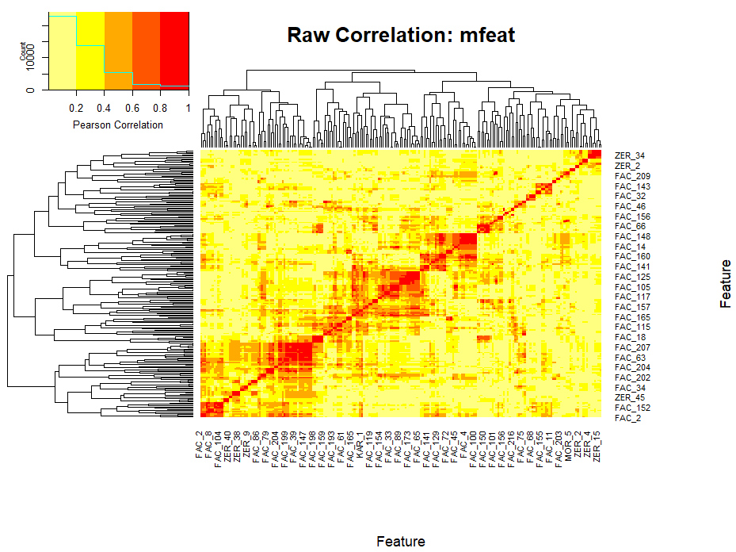

```r
featnames <- attr(datasetframeDecor[[1]],"varincluded")
cormat <- cor(datasetframe_test[,featnames],method="pearson")
gplots::heatmap.2(abs(cormat),
                  trace = "none",
                  scale = "none",
                  mar = c(10,10),
                  col=rev(heat.colors(5)),
                  main = paste("Raw Correlation:",studyName),
                  cexRow = 0.75,
                  cexCol = 0.75,
                  key.title=NA,
                  key.xlab="Pearson Correlation",
                  xlab="Feature", ylab="Feature")
```

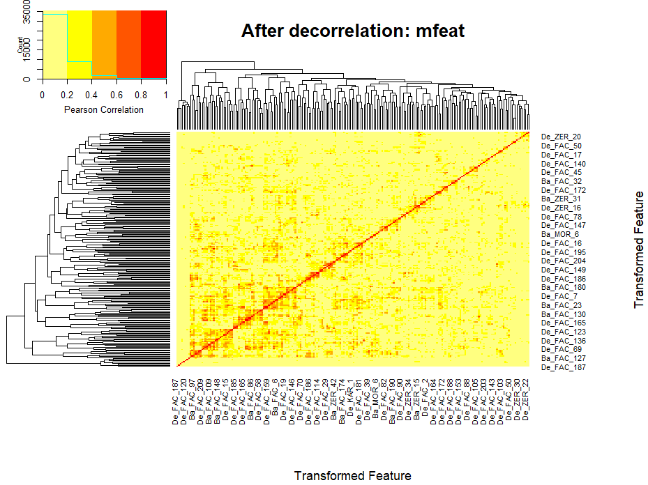

```r
featnames <- colnames(attr(datasetframeDecor[[1]],"GDSTM"))
cormat <- cor(decor_test[,featnames],method="pearson")
cormat[is.na(cormat)] <- 0;
gplots::heatmap.2(abs(cormat),
                  trace = "none",
                  scale = "none",
                  mar = c(10,10),
                  col=rev(heat.colors(5)),
                  main = paste("After decorrelation:",studyName),
                  cexRow = 0.75,
                  cexCol = 0.75,
                  key.title=NA,
                  key.xlab="Pearson Correlation",
                  xlab="Transformed Feature", ylab="Transformed Feature")
```

```r
NA
NA
```

The **GDSTMDecorrelation** function returns a data frame with the following column names:

The output features after transformation will be named after the original names and:

- The name will be unaltered if their maximum correlation to other features was lower than the threshold.
- The name will have the “Ba_” prefix is the feature was correlated but used as unaltered basis
- The name will have the “De_” prefix is the feature was original correlated and its correlation to “Ba_” features has been removed.

Furthermore, the returned data frame will have the following attributes:

1. Transformation matrix: “*GDSTM*”
2. Features:
   1. “*fsocre*”
   2. “*varincluded*”
   3. “*topFeatures*”
3. Unaltered Basis:
   1. “*baseFeatures*”
      1. “*correlatedToBase*”
   2. “*AbaseFeatures*”

### GDSTM

The “*GDSTM***“** attribute stores the spatial transformation matrix. The matrix only includes continuous features that had some correlation greater than the threshold

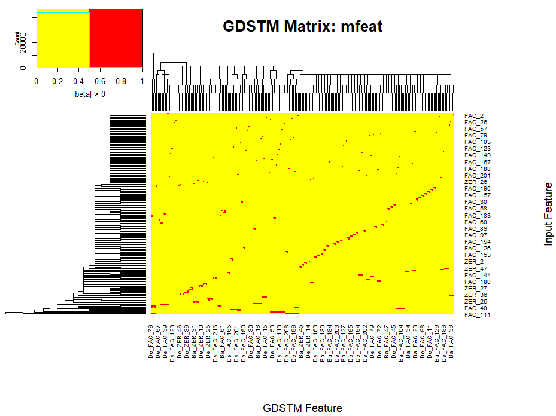

```r
## The Spatial Transformation Matrix:
GDSTM <- attr(datasetframeDecor[[1]],"GDSTM")

## The heatmap of the matrix
gplots::heatmap.2(1*(abs(GDSTM) > 0),
                  trace = "none",
                  mar = c(10,10),
                  col=rev(heat.colors(2)),
                  main = paste("GDSTM Matrix:",studyName),
                  cexRow = 0.7,
                  cexCol = 0.7,
                  breaks = c(0,0.5,1),
                  key.title=NA,
                  key.xlab="|beta| > 0",
                  xlab="GDSTM Feature", ylab="Input Feature")
```

```r
NA
NA
NA
```

### The Feature Index Score

The **FCA** analysis of the data features are stored in three attributes: “*varincluded*”, “*topFeatures*”, and “*fscore*”.

- “varincluded” returns the list of continuous features that were decorrelated
- “topFeatures” returns the features that at some point were used as independent variables inside the linear models.
- “fscore” : returns a named vector with the total feature score, $F_j$, of the analyzed features.

$$F_j=∑_{n}∑_{i∈B^{n}_{j}}|ρ_{i,j}|^2(|ρ_{i,j}|>ρ_{th}),~ \forall j \in Ind$$

$$F_j=F_j-∑_{n}|ρ_{B^n_j,j}|^2),~ \forall j \in Dep$$

where $B^n_j$ is the set of features statistically associated with feature *j* at iteration *n,* $ρ_{i,j}$ is the correlation between features *i,j*, and $ρ_{th}$ is the correlation goal, ${Ind, Dep}$ are the set of independent and dependent features respectively. In other words, the “*fscore”* indicates the degree of total association of”independent” features to dependent features.

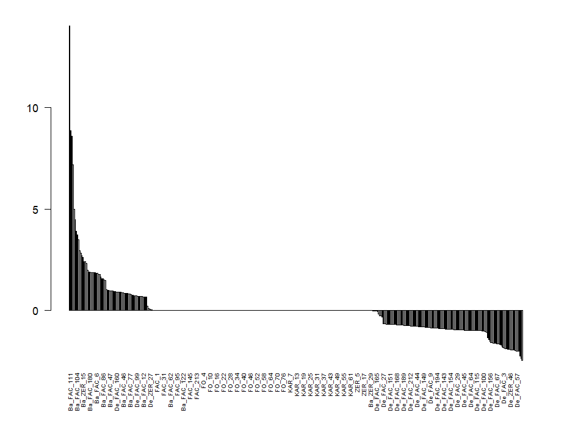

```r
fscore <- attr(datasetframeDecor[[1]],"fscore")
fscore <- fscore[order(-fscore)];
barplot(fscore,las=2,cex.names = 0.6)
```

## Machine Learning and GDSTM

Train a simple NB model on the raw dataset

```r
mNBRaw <- filteredFit(paste(Outcome,"~."),
                   datasetframe_train,
                   fitmethod=NAIVE_BAYES,
                     filtermethod=univariate_Wilcoxon,
                     filtermethod.control=list(pvalue=0.05,limit= 50),
                     pca=FALSE
                   )

# With PCA
mNBPCA <- filteredFit(paste(Outcome,"~."),
                   datasetframe_train,
                   fitmethod=NAIVE_BAYES,
                     filtermethod=univariate_Wilcoxon,
                     filtermethod.control=list(pvalue=0.05,limit= 50),
                     pca=TRUE
                   )
```

Now using the decorrelated data

```r
mNBDecor <- filteredFit(paste(Outcome,"~."),
                   datasetframeDecor[[1]],
                    fitmethod=NAIVE_BAYES,
                     filtermethod=univariate_Wilcoxon,
                     filtermethod.control=list(pvalue=0.05,limit= 50),
                     pca=FALSE
                   )
```

### The testing set predictions comparison

```r
# Predict the raw testing set
prRAW <- attr(predict(mNBRaw,datasetframe_test),"prob")

# Predict with PCA
prPCA <- attr(predict(mNBPCA,datasetframe_test),"prob")

# Predict the transformed dataset
prDecor <- attr(predict(mNBDecor,decor_test),"prob")


par(mfrow=c(1,3))
meanROCAUC <- numeric(3);
meanPCAROCAUC <- numeric(3);
classNames <- as.character(classNames)
for (theClass in classNames)
{
  classoutcomes <- 1*(datasetframe_test[,Outcome] == theClass)
  psRaw <- predictionStats_binary(cbind(classoutcomes,prRAW[,theClass]),
                                paste("Raw :",theClass),cex=0.75)
  pander::pander(psRaw$aucs)
  psPCA <- predictionStats_binary(cbind(classoutcomes,prPCA[,theClass]),
                                paste("PCA :",theClass),cex=0.75)
  pander::pander(psPCA$aucs)
  psDecor <- predictionStats_binary(cbind(classoutcomes,prDecor[,theClass]),
                                paste("GDSTM :",theClass),cex=0.75)
  pander::pander(psDecor$aucs)
  meanROCAUC <- meanROCAUC + psRaw$aucs;
  meanPCAROCAUC <- meanPCAROCAUC + psPCA$aucs;
}
```

Raw : 0

| est | lower | upper |
| --- | --- | --- |
| 1 | 0.9999 | 1 |

PCA : 0

| est | lower | upper |
| --- | --- | --- |
| 0.976 | 0.9487 | 1 |

GDSTM : 0

| est | lower | upper |
| --- | --- | --- |
| 0.9999 | 0.9998 | 1 |

Raw : 1

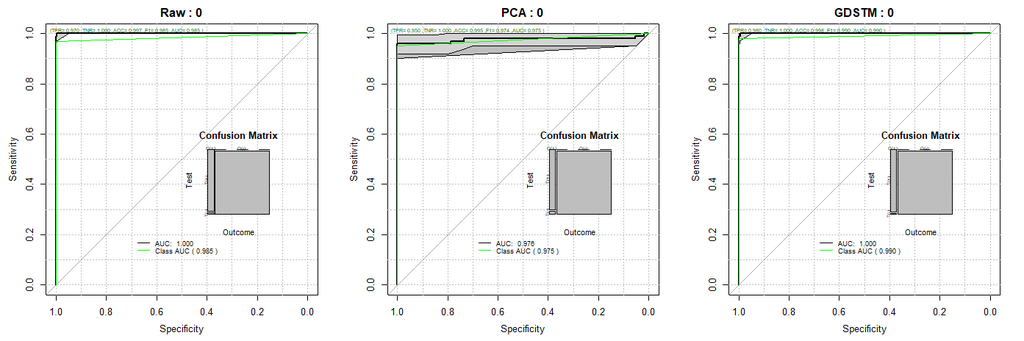

| est | lower | upper |
| --- | --- | --- |
| 0.9993 | 0.9985 | 1 |

PCA : 1

| est | lower | upper |
| --- | --- | --- |
| 0.9721 | 0.9516 | 0.9925 |

GDSTM : 1

| est | lower | upper |
| --- | --- | --- |
| 0.9991 | 0.9982 | 1 |

Raw : 2

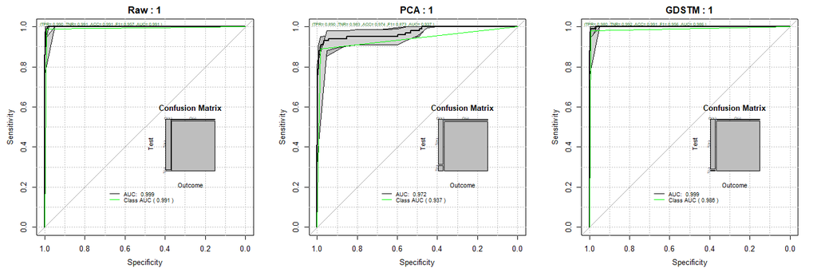

| est | lower | upper |
| --- | --- | --- |
| 1 | 0.9999 | 1 |

PCA : 2

| est | lower | upper |
| --- | --- | --- |
| 0.9984 | 0.9961 | 1 |

GDSTM : 2

| est | lower | upper |
| --- | --- | --- |
| 0.9999 | 0.9996 | 1 |

Raw : 3

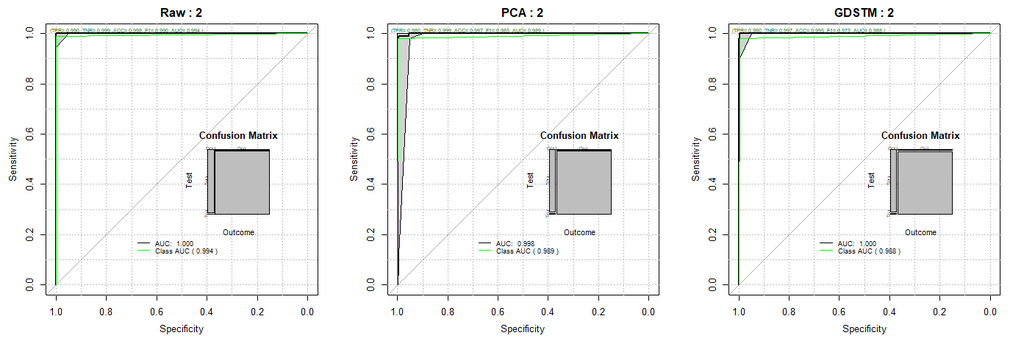

| est | lower | upper |
| --- | --- | --- |
| 0.997 | 0.9941 | 0.9998 |

PCA : 3

| est | lower | upper |
| --- | --- | --- |
| 0.9561 | 0.9213 | 0.991 |

GDSTM : 3

| est | lower | upper |
| --- | --- | --- |
| 0.9984 | 0.9968 | 0.9999 |

Raw : 4

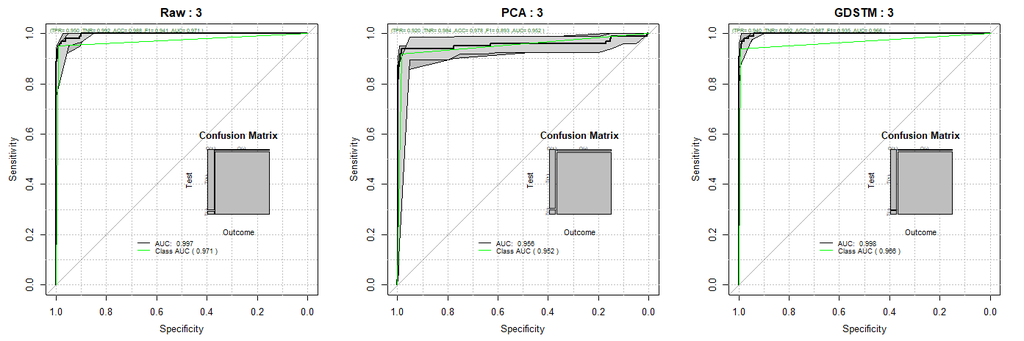

| est | lower | upper |
| --- | --- | --- |
| 0.9997 | 0.9993 | 1 |

PCA : 4

| est | lower | upper |
| --- | --- | --- |
| 0.9905 | 0.9813 | 0.9997 |

GDSTM : 4

| est | lower | upper |
| --- | --- | --- |
| 0.9999 | 0.9997 | 1 |

Raw : 5

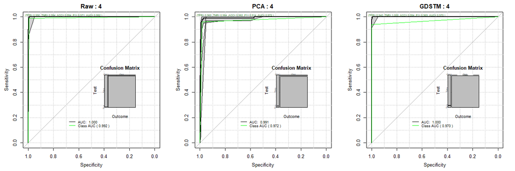

| est | lower | upper |
| --- | --- | --- |
| 0.9982 | 0.996 | 1 |

PCA : 5

| est | lower | upper |
| --- | --- | --- |
| 0.9775 | 0.9527 | 1 |

GDSTM : 5

| est | lower | upper |
| --- | --- | --- |
| 0.9994 | 0.9986 | 1 |

Raw : 6

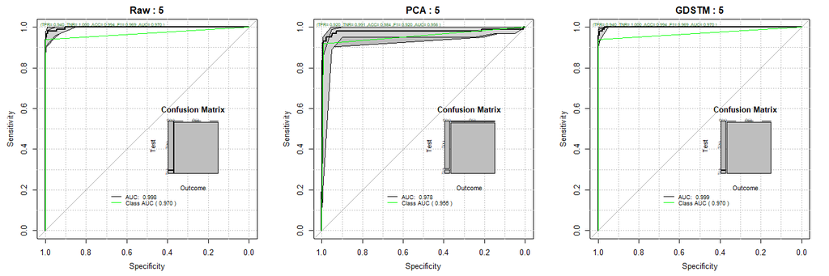

| est | lower | upper |
| --- | --- | --- |
| 0.9999 | 0.9997 | 1 |

PCA : 6

| est | lower | upper |
| --- | --- | --- |
| 0.9849 | 0.974 | 0.9959 |

GDSTM : 6

| est | lower | upper |
| --- | --- | --- |
| 1 | 0.9999 | 1 |

Raw : 7

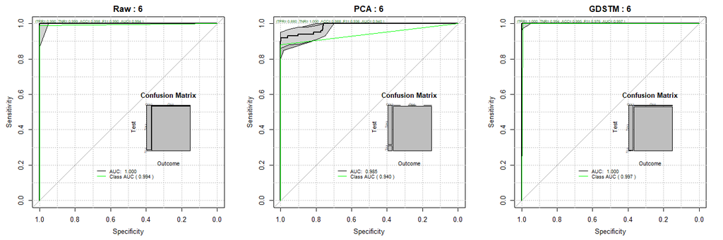

| est | lower | upper |
| --- | --- | --- |
| 0.9998 | 0.9996 | 1 |

PCA : 7

| est | lower | upper |
| --- | --- | --- |
| 0.9883 | 0.9787 | 0.998 |

GDSTM : 7

| est | lower | upper |
| --- | --- | --- |
| 0.9999 | 0.9996 | 1 |

Raw : 8

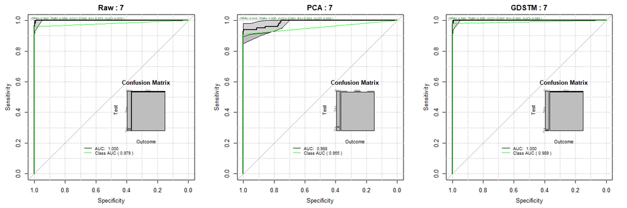

| est | lower | upper |
| --- | --- | --- |
| 0.9996 | 0.999 | 1 |

PCA : 8

| est | lower | upper |
| --- | --- | --- |
| 0.9803 | 0.9575 | 1 |

GDSTM : 8

| est | lower | upper |
| --- | --- | --- |
| 0.9982 | 0.9948 | 1 |

Raw : 9

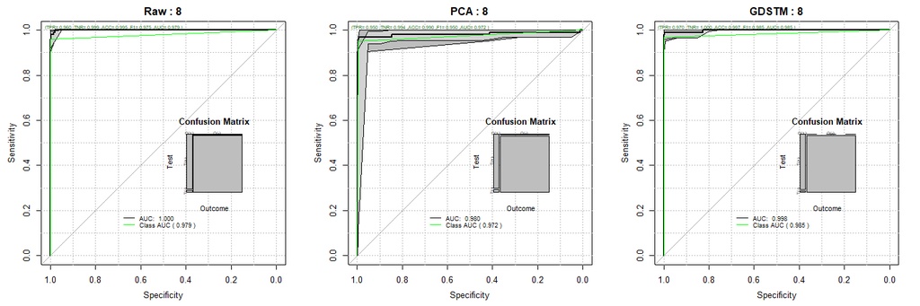

| est | lower | upper |
| --- | --- | --- |
| 0.9998 | 0.9994 | 1 |

PCA : 9

| est | lower | upper |
| --- | --- | --- |
| 0.9911 | 0.9762 | 1 |

GDSTM : 9

| est | lower | upper |
| --- | --- | --- |
| 0.9996 | 0.9987 | 1 |

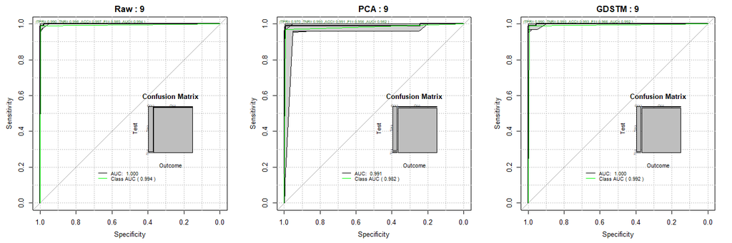

```r
meanROCAUC <- meanROCAUC/length(classNames)
AllRocAUC <- meanROCAUC;
meanPCAROCAUC <- meanPCAROCAUC/length(classNames)
AllRocAUC <- rbind(AllRocAUC,meanPCAROCAUC);
```

## Comparing FCA Options predictions

The following code runs the function and selecting some of the possible options:

```r
# Change the maximum correlation goal

decortype[[2]] <- "AtThr"
system.time(datasetframeDecor[[2]] <- GDSTMDecorrelation(
  datasetframe_train,
  thr = correlationThreshold
  ))
```

user system elapsed 1.62 0.08 1.64

```r
# Change the maximum correlation goal, and set to Robust Liner Models
decortype[[3]] <- "RLM_Pearson"
system.time(datasetframeDecor[[3]] <- GDSTMDecorrelation(
  datasetframe_train,
  type="RLM",
  method="pearson"))
```

user system elapsed 6.75 0.03 6.96

```r
# Change the maximum correlation goal, and change to Spearman correlation
decortype[[4]] <- "LM_Spearman"
system.time(datasetframeDecor[[4]] <- GDSTMDecorrelation(
  datasetframe_train,
  type="LM",
  method="spearman"))
```

user system elapsed 2.53 0.06 2.52

```r
# Change the maximum correlation goal, and set Spearman correlation with robust liner model
decortype[[5]] <- "RLM_Spearman"
system.time(datasetframeDecor[[5]] <- GDSTMDecorrelation(
  datasetframe_train,
  type="RLM",
  method="spearman"))
```

user system elapsed 6.22 0.05 6.20

```r
# The following are for supervised basis learning

# Set the target class for association learning
decortype[[6]] <- "Sup_Default"
system.time(datasetframeDecor[[6]] <- GDSTMDecorrelation(
  datasetframe_train,
  Outcome=Outcome))
```

user system elapsed 1.20 0.06 1.07

```r
# Change the maximum correlation goal
decortype[[7]] <- "Sup_AtThr"
system.time(datasetframeDecor[[7]] <- GDSTMDecorrelation(
  datasetframe_train,
  Outcome=Outcome))
```

user system elapsed 1.03 0.05 0.91

```r
# Change the maximum correlation goal, and set to Robust Liner Models
decortype[[8]] <- "Sup_RLM_Pearson"
system.time(datasetframeDecor[[8]] <- GDSTMDecorrelation(
  datasetframe_train,
  Outcome=Outcome,
  type="RLM",
  method="pearson"))
```

user system elapsed 6.38 0.02 6.44

```r
# Change the maximum correlation goal, and change to Spearman correlation
decortype[[9]] <- "Sup_LM_Spearman"
system.time(datasetframeDecor[[9]] <- GDSTMDecorrelation(
  datasetframe_train,
  Outcome=Outcome,
  type="LM",
  method="spearman"))
```

user system elapsed 2.66 0.08 2.66

```r
# Change the maximum correlation goal, and set to Spearman correlation with robust liner model
decortype[[10]] <- "Sup_RLM_Spearman"
system.time(datasetframeDecor[[10]] <- GDSTMDecorrelation(
  datasetframe_train,
  Outcome=Outcome,
  type="RLM",
  method="spearman"))
```

user system elapsed 6.72 0.03 6.70

```r
# With user defined supervised basis
decortype[[11]] <- "Sup_KS_RLM_Spearman"
baseKS <- names(univariate_KS(datasetframe_train,
                        Outcome=Outcome,
                        pvalue=0.20,
                        limit=0,
                        thr=correlationThreshold))

system.time(datasetframeDecor[[11]] <- GDSTMDecorrelation(
  datasetframe_train,
  Outcome=Outcome,
  baseFeatures=baseKS,
  type="RLM",
  method="spearman"))
```

user system elapsed 6.98 0.08 7.08

## Predict on all set of transformations

```r
par(mfrow=c(2,5))

for (i in c(1:length(datasetframeDecor)))
{
  mNBDecor <- filteredFit(paste(Outcome,"~."),
                   datasetframeDecor[[i]],
                    fitmethod=NAIVE_BAYES,
                     filtermethod=univariate_Wilcoxon,
                     filtermethod.control=list(pvalue=0.05,limit= 50),
                     pca=FALSE
                   )

  decor_test <- predictDecorrelate(datasetframeDecor[[i]],datasetframe_test)
  prDecor <- attr(predict(mNBDecor,decor_test),"prob")
  meanROCAUC <- numeric(3);
  for (theClass in classNames)
  {
    classoutcomes <- 1*(datasetframe_test[,Outcome] == theClass)
    psDecor <- predictionStats_binary(cbind(classoutcomes,prDecor[,theClass]),
                                  paste(decortype[[i]],theClass,sep=":"),cex=0.5)
    meanROCAUC <- meanROCAUC + psDecor$aucs;
  }
  meanROCAUC <- meanROCAUC/length(classNames)
  pander::pander(meanROCAUC)
  AllRocAUC <- rbind(AllRocAUC,meanROCAUC)

}
```

Default:0 Default:1 Default:2 Default:3 Default:4 Default:5 Default:6 Default:7 Default:8 Default:9

| est | lower | upper |
| --- | --- | --- |
| 0.9994 | 0.9985 | 1 |

AtThr:0

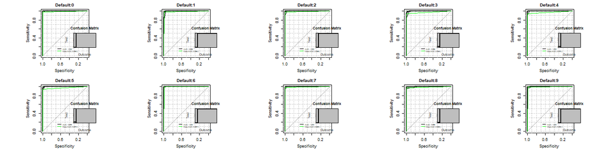

AtThr:1 AtThr:2 AtThr:3 AtThr:4 AtThr:5 AtThr:6 AtThr:7 AtThr:8 AtThr:9

| est | lower | upper |
| --- | --- | --- |
| 0.9986 | 0.9968 | 1 |

RLM_Pearson:0

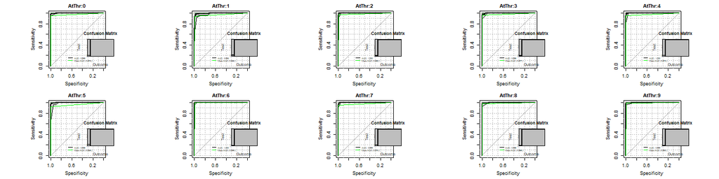

RLM_Pearson:1 RLM_Pearson:2 RLM_Pearson:3 RLM_Pearson:4 RLM_Pearson:5 RLM_Pearson:6 RLM_Pearson:7 RLM_Pearson:8 RLM_Pearson:9

| est | lower | upper |
| --- | --- | --- |
| 0.9988 | 0.9973 | 1 |

LM_Spearman:0

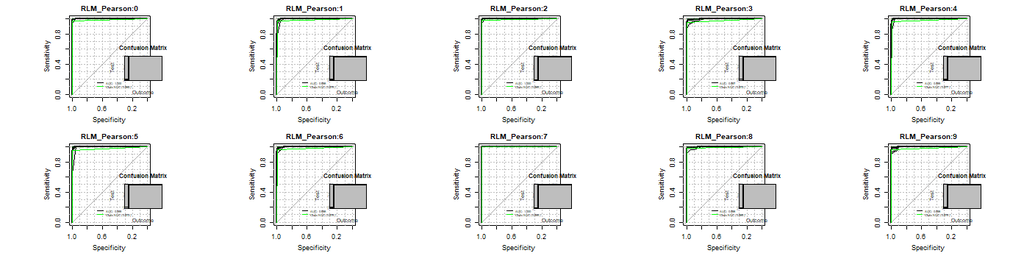

LM_Spearman:1 LM_Spearman:2 LM_Spearman:3 LM_Spearman:4 LM_Spearman:5 LM_Spearman:6 LM_Spearman:7 LM_Spearman:8 LM_Spearman:9

| est | lower | upper |
| --- | --- | --- |
| 0.9994 | 0.9986 | 0.9999 |

RLM_Spearman:0

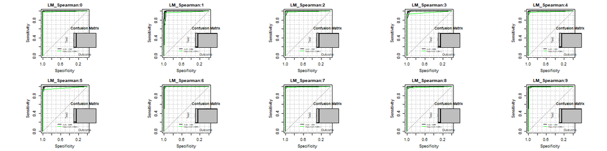

RLM_Spearman:1 RLM_Spearman:2 RLM_Spearman:3 RLM_Spearman:4 RLM_Spearman:5 RLM_Spearman:6 RLM_Spearman:7 RLM_Spearman:8 RLM_Spearman:9

| est | lower | upper |
| --- | --- | --- |
| 0.9993 | 0.9983 | 1 |

Sup_Default:0

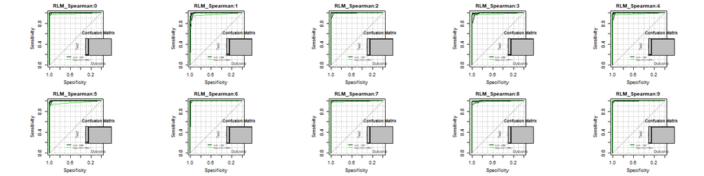

Sup_Default:1 Sup_Default:2 Sup_Default:3 Sup_Default:4 Sup_Default:5 Sup_Default:6 Sup_Default:7 Sup_Default:8 Sup_Default:9

| est | lower | upper |
| --- | --- | --- |
| 0.9983 | 0.9962 | 1 |

Sup_AtThr:0

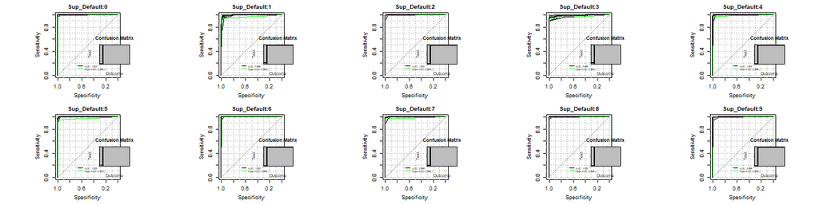

Sup_AtThr:1 Sup_AtThr:2 Sup_AtThr:3 Sup_AtThr:4 Sup_AtThr:5 Sup_AtThr:6 Sup_AtThr:7 Sup_AtThr:8 Sup_AtThr:9

| est | lower | upper |
| --- | --- | --- |
| 0.9983 | 0.9961 | 1 |

Sup_RLM_Pearson:0

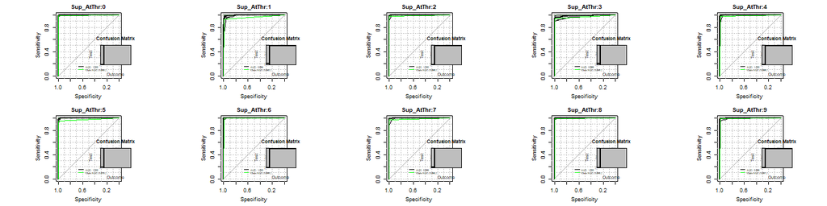

Sup_RLM_Pearson:1 Sup_RLM_Pearson:2 Sup_RLM_Pearson:3 Sup_RLM_Pearson:4 Sup_RLM_Pearson:5 Sup_RLM_Pearson:6 Sup_RLM_Pearson:7 Sup_RLM_Pearson:8 Sup_RLM_Pearson:9

| est | lower | upper |
| --- | --- | --- |
| 0.9969 | 0.9937 | 0.9998 |

Sup_LM_Spearman:0

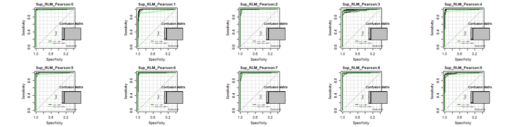

Sup_LM_Spearman:1 Sup_LM_Spearman:2 Sup_LM_Spearman:3 Sup_LM_Spearman:4 Sup_LM_Spearman:5 Sup_LM_Spearman:6 Sup_LM_Spearman:7 Sup_LM_Spearman:8 Sup_LM_Spearman:9

| est | lower | upper |
| --- | --- | --- |
| 0.9991 | 0.9979 | 1 |

Sup_RLM_Spearman:0

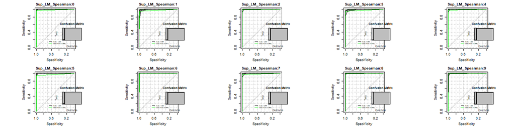

Sup_RLM_Spearman:1 Sup_RLM_Spearman:2 Sup_RLM_Spearman:3 Sup_RLM_Spearman:4 Sup_RLM_Spearman:5 Sup_RLM_Spearman:6 Sup_RLM_Spearman:7 Sup_RLM_Spearman:8 Sup_RLM_Spearman:9

| est | lower | upper |
| --- | --- | --- |
| 0.9989 | 0.9978 | 0.9999 |

Sup_KS_RLM_Spearman:0

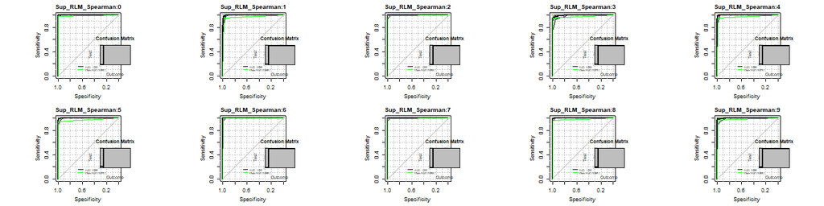

Sup_KS_RLM_Spearman:1 Sup_KS_RLM_Spearman:2 Sup_KS_RLM_Spearman:3 Sup_KS_RLM_Spearman:4 Sup_KS_RLM_Spearman:5 Sup_KS_RLM_Spearman:6 Sup_KS_RLM_Spearman:7 Sup_KS_RLM_Spearman:8 Sup_KS_RLM_Spearman:9

| est | lower | upper |
| --- | --- | --- |
| 0.9991 | 0.9981 | 1 |

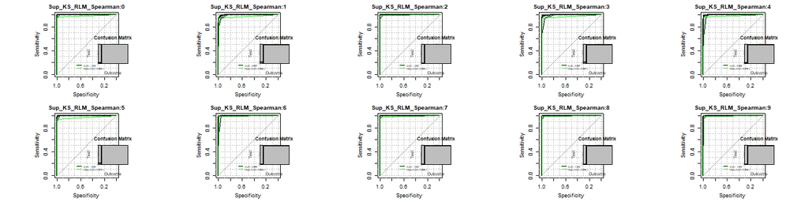

### The Bar plot of all AUC

```r
rownames(AllRocAUC) <- c("Raw","PCA",unlist(decortype))
pander::pander(AllRocAUC)
```

|  | est | lower | upper |
| --- | --- | --- | --- |
| **Raw** | 0.9993 | 0.9985 | 1 |
| **PCA** | 0.9815 | 0.9638 | 0.9977 |
| **Default** | 0.9994 | 0.9985 | 1 |
| **AtThr** | 0.9986 | 0.9968 | 1 |
| **RLM_Pearson** | 0.9988 | 0.9973 | 1 |
| **LM_Spearman** | 0.9994 | 0.9986 | 0.9999 |
| **RLM_Spearman** | 0.9993 | 0.9983 | 1 |
| **Sup_Default** | 0.9983 | 0.9962 | 1 |
| **Sup_AtThr** | 0.9983 | 0.9961 | 1 |
| **Sup_RLM_Pearson** | 0.9969 | 0.9937 | 0.9998 |
| **Sup_LM_Spearman** | 0.9991 | 0.9979 | 1 |
| **Sup_RLM_Spearman** | 0.9989 | 0.9978 | 0.9999 |
| **Sup_KS_RLM_Spearman** | 0.9991 | 0.9981 | 1 |

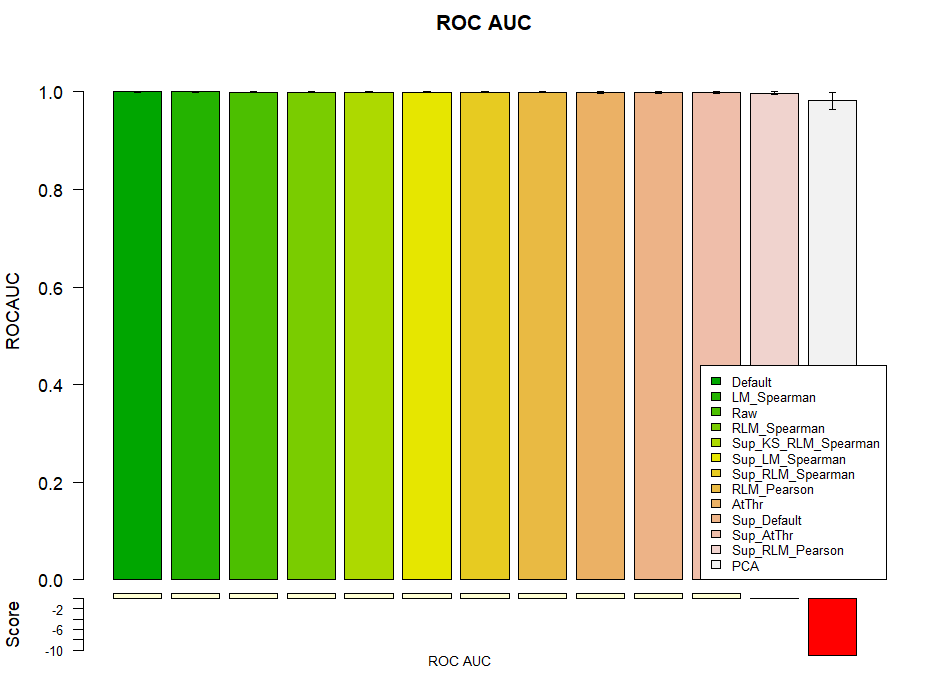

```r
par(mfrow=c(1,1))

bpROCAUC <- barPlotCiError(as.matrix(AllRocAUC),
                          metricname = "ROCAUC",
                          thesets = "ROC AUC",
                          themethod = rownames(AllRocAUC),
                          main = "ROC AUC",
                          offsets = c(0.5,1),
                          scoreDirection = ">",
                          ho=0.5,
                          args.legend = list(bg = "white",x="bottomright",inset=c(0.0,0),cex=0.75),
                          col = terrain.colors(nrow(AllRocAUC))
                          )
```